# Assignment

Kaisu Hiltunen

2023-05-17

# Week 10 assignment

```r
suppressPackageStartupMessages({
  library(GenomicRanges)
  library(epiwraps)
  library(ggplot2)
  library(rGREAT)
})
```

## Data

We download and decompress the following archive: https://ethz-ins.org/content/w10.assignment.zip This contains the bigwig files and peaks (bed) files for three TFs of the CREB family (all restricted to chr1; aligned against the hg38 genome)

## Download the data

```r
options(timeout = 6000)
dir.create("C:/Users/kaisu/OneDrive - Aalto University/Kurssit/Bioinformatic_approaches/ethEpigen2023_materials/ethEpigen2023_materials/week10/assignment")
download.file("https://ethz-ins.org/content/w10.assignment.zip", "w10.assignment.zip")
unzip("w10.assignment.zip")

list.files()
```

## Prepare the regions and the tracks

To get a clearer picture, we focus on high-confidence peaks from each factor to define the universe of regions. The non-redundant regions are obtained using the reduce() function.

```r
tracks <- list.files(pattern="bw$")
peaks <- list.files(pattern="bed$")
# we first import the peaks
peaks <- lapply(peaks, rtracklayer::import.bed)
# we'll focus on the high-quality peaks
peaks <- lapply(peaks, FUN=function(x) x[x$score>800])
# we get the union of non-redundant regions
regions <- reduce(unlist(GRangesList(peaks)))
```

## Plotting and clustering

We use clustering and visualization to illustrate the relationship between the binding of the different proteins.The lines are sorted in vertical direction by intensity.

```r
#The signal for each TF is calculated
ml <- signal2Matrix(tracks, regions, extend=2000)
```

```
## Reading Creb1.bw
```

```
## Reading Creb3.bw
```

```
## Reading Creb3L1.bw
```

```
## 'magick' package is suggested to install to give better rasterization.
##
## Set `ht_opt$message = FALSE` to turn off this message.
```

[output not shown]

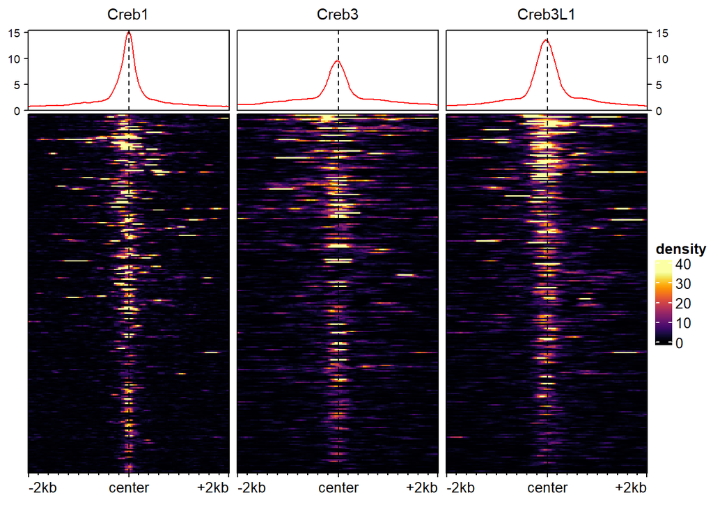

```r
# we could do extra normalization if needed
# nf <- getNormFactors(tracks, useSeqLevels="chr1")
# ml <- rescaleSignalMatrices(ml, scaleFactors=nf)

plotEnrichedHeatmaps(ml)
```

The above is not great for observing patterns. It could be easier to see patterns if we sort the lines in clusters of similar signal. Clustering is performed using k-means clustering with different numbers of clusters, and the proportion of variance explained is plotted. The k-means algorithm aims to partition n observations into k clusters in which each observation belongs to the cluster with the nearest mean.In this case, each observation represents a genomic region and the signal (ChIP-seq signal) of each transcription factor is used to calculate the distance between the observations.

After trying different numbers of clusters we can see that the elbow lies at cl=3.

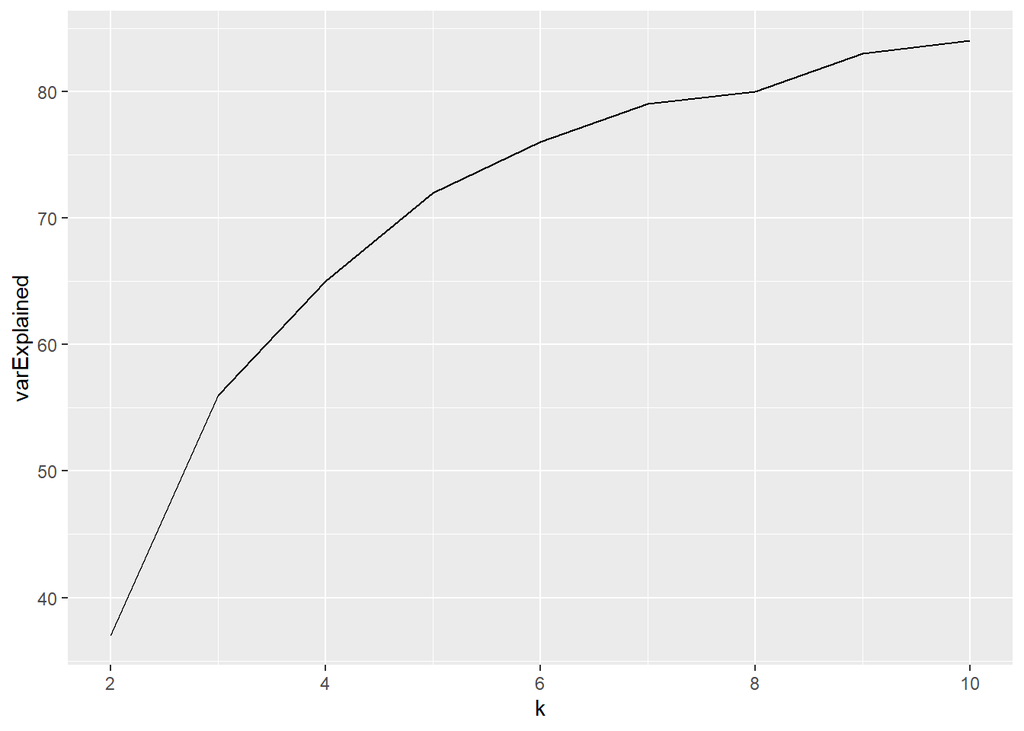

```r
cls<-clusterSignalMatrices(ml,k=2:10)
ggplot(cls$varExplained, aes(k, varExplained))+geom_line()
```

The clusters explain ~56 % of the variation

```r
#clustering with a function
#uses k-mean clustering
cl<-clusterSignalMatrices(ml, k=3)
```

```
##   ~56% of the variance explained by clusters
```

```r
regions$cluster<-cl
```

Each region is assigned to a cluster, and the clusters are plotted using a heatmap where similar clusters are grouped together. This helps to visualize the relationships between the transcription factors based on the clustering. Important to use s cl based on the ml.

[output not shown]

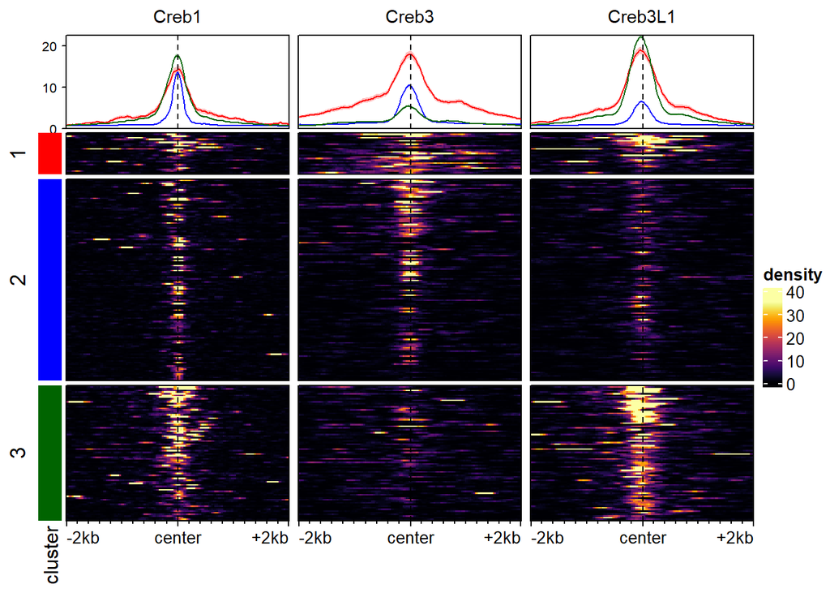

```r
mycolors<-c("1"="red", "2"="blue", "3"="darkgreen") #"4"="black")
plotEnrichedHeatmaps(ml, row_split = cl, mean_color=mycolors)
```

## Enrichment analysis

We use GO enrichment analysis to determine if there are any enriched biological functions associated with the regions in each cluster.

```r
sp<- split(regions, cl)

#sends both regions of interests as well as the background of regions to a remote
#server.
res_cluster3<-rGREAT::submitGreatJob(sp[["3"]], bg=regions, species="hg38")
table_cluster3<-rGREAT::getEnrichmentTables(res_cluster3)

res_cluster2<-rGREAT::submitGreatJob(sp[["2"]], bg=regions, species="hg38")
table_cluster2<-rGREAT::getEnrichmentTables(res_cluster2)

res_cluster1<-rGREAT::submitGreatJob(sp[["1"]], bg=regions, species="hg38")
```

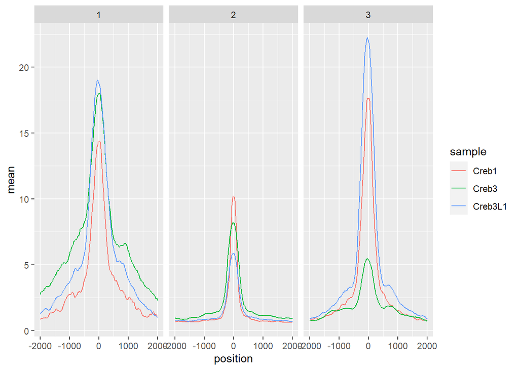

```r
table_cluster1<-rGREAT::getEnrichmentTables(res_cluster1)

bp_cl1<-table_cluster1$`GO Biological Process`
bp_cl2<-table_cluster2$`GO Biological Process`
bp_cl3<-table_cluster3$`GO Biological Process`

d<-meltSignals(ml,splitBy = cl)
ggplot(d, aes(position, mean, colour=sample))+geom_line()+facet_wrap(~split)
```

## Using the relative signal

Below is an example of clustering using the relative signal instead. This does not work when regions contains places where nothing happens. We have filtered the redundant regions so this should not be an issue.

```r
cl_rela<-clusterSignalMatrices(ml, k=3, scaleRows=TRUE)
```

```
##   ~80% of the variance explained by clusters
```

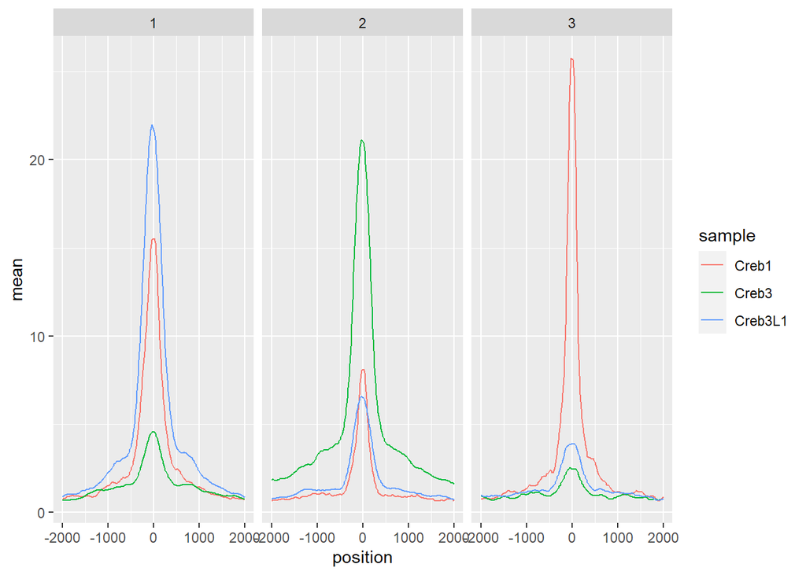

```r
d_rela<-meltSignals(ml,splitBy = cl_rela)
ggplot(d_rela, aes(position, mean, colour=sample))+geom_line()+facet_wrap(~split)
```

[output not shown]

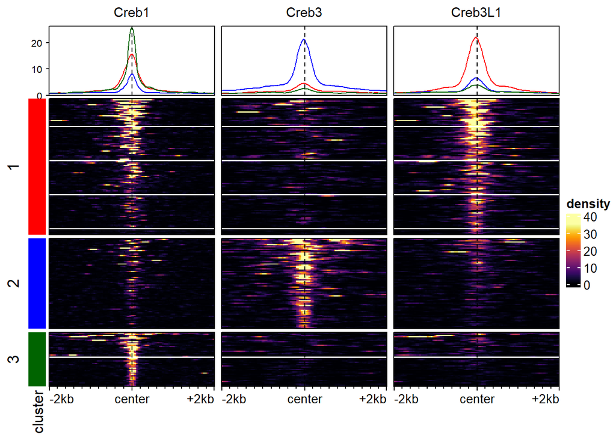

```r
plotEnrichedHeatmaps(ml, row_split = cl_rela, mean_color=mycolors)
```

```r
sp_rela<- split(regions, cl_rela)

#sends both regions of interests as well as the background of regions to a remote
#server.
res_rela_3<-rGREAT::submitGreatJob(sp_rela[["3"]], bg=regions, species="hg38")
table_cluster3_rela<-rGREAT::getEnrichmentTables(res_rela_3)
bp_cl3_rela <- table_cluster3_rela$`GO Biological Process`

res_rela_2<-rGREAT::submitGreatJob(sp_rela[["2"]], bg=regions, species="hg38")
table_cluster2_rela<-rGREAT::getEnrichmentTables(res_rela_2)
bp_cl2_rela <- table_cluster2_rela$`GO Biological Process`

res_rela_1<-rGREAT::submitGreatJob(sp_rela[["1"]], bg=regions, species="hg38")
table_cluster1_rela<-rGREAT::getEnrichmentTables(res_rela_1)
bp_cl1_rela <- table_cluster1_rela$`GO Biological Process`
```

## Cluster 1

These plots are included for comparison but are not discussed in this assignment as the results are less significant.

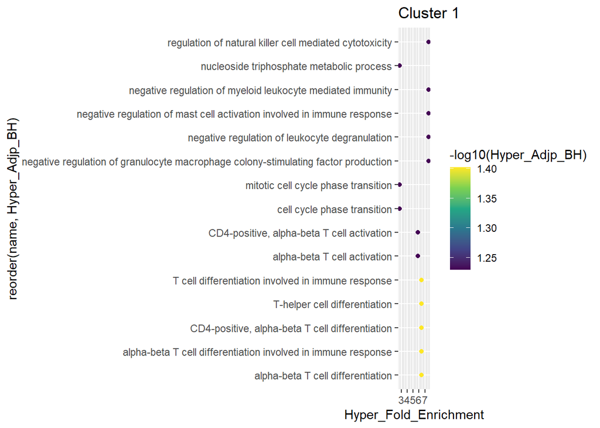

```r
par(mfrow=c(1,2))
ggplot(head(bp_cl1,15), aes(Hyper_Fold_Enrichment, reorder(name, Hyper_Adjp_BH), color=-log10(Hyper_Adjp_BH))) + geom_point() + scale_color_viridis_c()+ggtitle("Cluster 1")
```

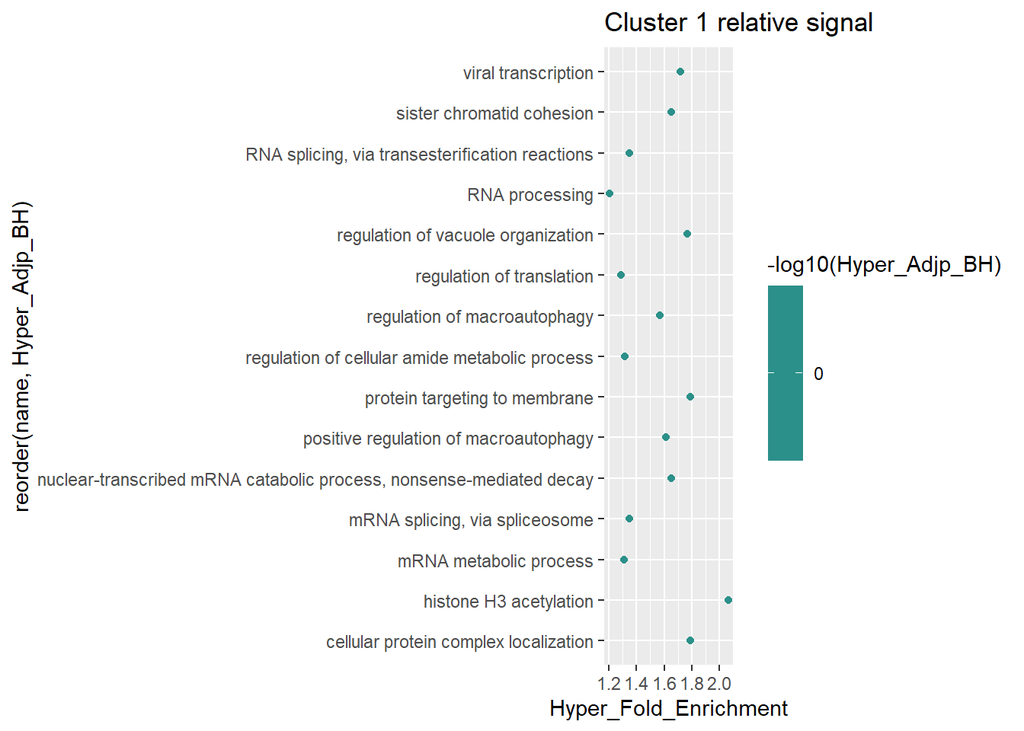

```r
ggplot(head(bp_cl1_rela,15), aes(Hyper_Fold_Enrichment, reorder(name, Hyper_Adjp_BH), color=-log10(Hyper_Adjp_BH))) + geom_point() + scale_color_viridis_c()+ggtitle("Cluster 1 relative signal")
```

## Cluster 2

Both the unprocessed signal and the relative signal clusters have differentially expressed GO terms. In the cluster, where the signal rows were scaled, the top 3 significant biological processes are

```r
head(bp_cl2_rela,15)
```

```
##            ID                                                    name
## 1  GO:0050896                                    response to stimulus
## 2  GO:0051716                           cellular response to stimulus
## 3  GO:0032649               regulation of interferon-gamma production
## 4  GO:0007154                                      cell communication
## 5  GO:0023052                                               signaling
## 6  GO:0044700                               single organism signaling
## 7  GO:0006955                                         immune response
## 8  GO:0002250                                adaptive immune response
## 9  GO:0032729      positive regulation of interferon-gamma production
## 10 GO:0007165                                     signal transduction
## 11 GO:0051240 positive regulation of multicellular organismal process
## 12 GO:0002684            positive regulation of immune system process
## 13 GO:0002376                                   immune system process
## 14 GO:0008284               positive regulation of cell proliferation
```

[output cut: 65 more lines]

Each row represents a specific GO term, and the columns provide information about the term’s ID, term description, the number of genes associated with the term (count), the expected count of genes based on the background, the fold enrichment (ratio of observed count to expected count), and the p-value or statistical significance. In the unscaled signal, these are the top 3 GO processes.

```r
head(bp_cl2,3)
```

```
##           ID                             name Hyper_Total_Regions
## 1 GO:0032501 multicellular organismal process                1119
## 2 GO:0023052                        signaling                 897
## 3 GO:0044700        single organism signaling                 895
##   Hyper_Expected Hyper_Foreground_Region_Hits Hyper_Fold_Enrichment
## 1       596.7342                          692              1.159645
## 2       478.3473                          564              1.179060
## 3       477.2807                          562              1.177504
##   Hyper_Region_Set_Coverage Hyper_Term_Region_Coverage
## 1                 0.5719008                  0.6184093
## 2                 0.4661157                  0.6287625
## 3                 0.4644628                  0.6279330
##   Hyper_Foreground_Gene_Hits Hyper_Background_Gene_Hits Total_Genes_Annotated
## 1                        384                        471                  6553
## 2                        317                        380                  5085
## 3                        316                        379                  5081
##   Hyper_Raw_PValue Hyper_Adjp_BH
## 1     6.428741e-16  8.459580e-12
## 2     9.404826e-14  6.187905e-10
## 3     1.683841e-13  7.385888e-10
```

The differences between these two methods are small, but clearly the rowscaling affects the outcome.

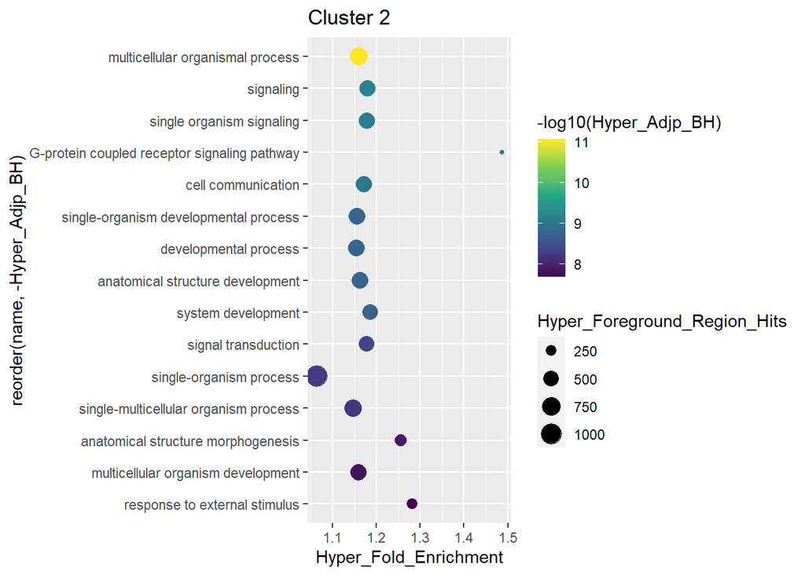

```r
par(mfrow=c(1,2))
ggplot(head(bp_cl2,15), aes(Hyper_Fold_Enrichment, reorder(name, -Hyper_Adjp_BH), size=Hyper_Foreground_Region_Hits, color=-log10(Hyper_Adjp_BH))) + geom_point() + scale_color_viridis_c()+ggtitle("Cluster 2")
```

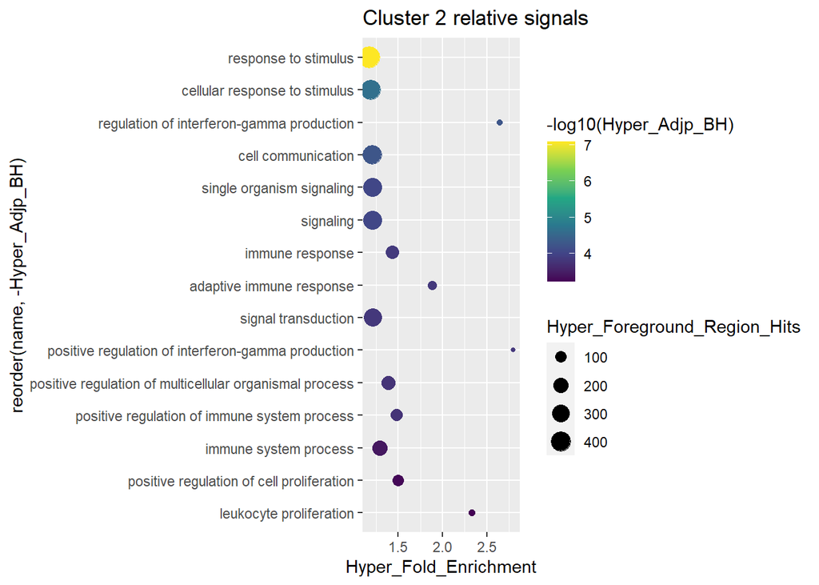

```r
ggplot(head(bp_cl2_rela,15), aes(Hyper_Fold_Enrichment, reorder(name, -Hyper_Adjp_BH), size=Hyper_Foreground_Region_Hits, color=-log10(Hyper_Adjp_BH))) + geom_point() + scale_color_viridis_c()+ggtitle("Cluster 2 relative signals")
```

## Cluster 3

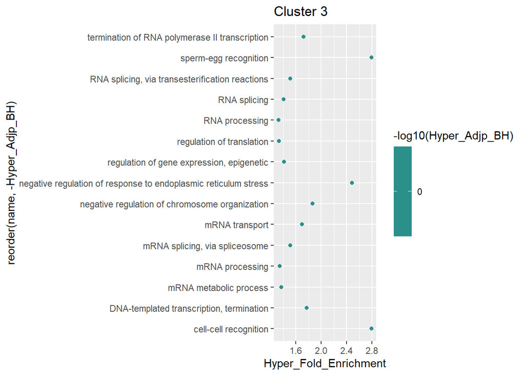

```r
par(mfrow=c(1,2))
ggplot(head(bp_cl3,15), aes(Hyper_Fold_Enrichment, reorder(name, -Hyper_Adjp_BH), color=-log10(Hyper_Adjp_BH))) + geom_point() + scale_color_viridis_c()+ggtitle("Cluster 3")
```

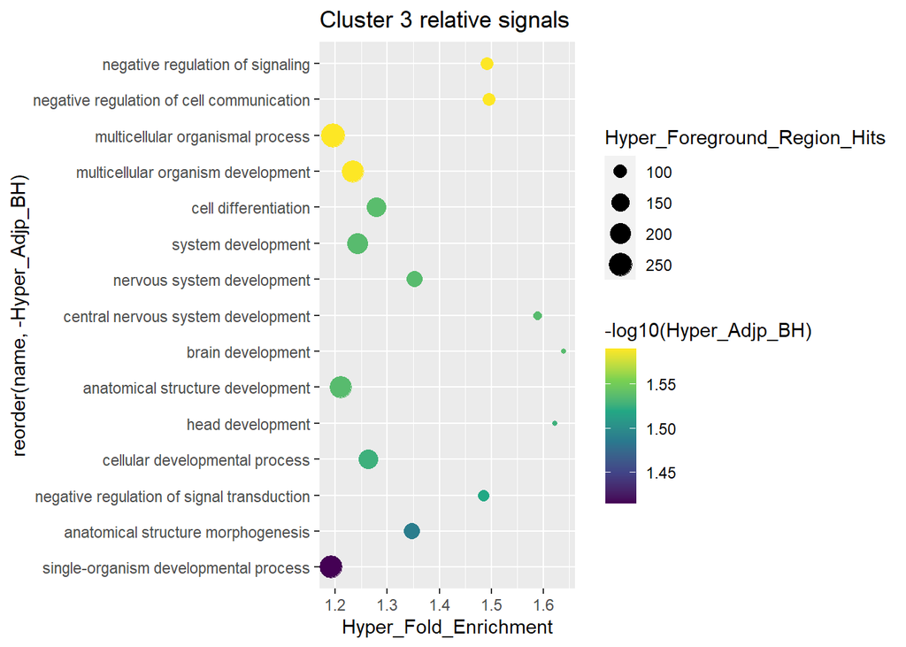

```r
ggplot(head(bp_cl3_rela,15), aes(Hyper_Fold_Enrichment, reorder(name, -Hyper_Adjp_BH), size=Hyper_Foreground_Region_Hits, color=-log10(Hyper_Adjp_BH))) + geom_point() + scale_color_viridis_c()+ggtitle("Cluster 3 relative signals")
```